# FISABIO-HSRP OMOP ETL design v3.1

Author

Francisco Sanchez-Saez

Published

June 14, 2024

# DOCUMENT HISTORY

Table 1: version changelog

Version Number

Date

Changes

1.0

2023-02-23

1.1

2023-04-06

1. The pipeline of FISABIO-HSRP unit for the ETL VID-OMOP has been updated. The curation of the source tables before the transformation process has been enhanced. Additionally, a source data quality check has been implemented to distinguish between potential issues in the source data and potential issues in the transformation to the OMOP CDM process. The following changes have been made:

   - The **GAIA** table, which is a processed table, has been redesigned, and the source tables that make it up (**pres**, **fact**, **rele**, and **tx**) have been added.

   - The **CONG** table, which contains information about congenital anomalies, has been added.

   - A new column, *mandatory*, indicating if it is mandatory to extract a variable in the source table, has been added.

2. Some variable names of the source tables have been updated in the data dictionary and the data mapping section:

   - In **CEX**:

     - *fecha* has been updated to *fecha_consulta*.

   - In **AED**:

     - *momento_reg* has been updated to *fecha_registro*.

     - *momento_alta* has been updated to *fecha_alta*.

   - In **EOS**:

     - *id_embarazo* has been updated to *embarazo_id*.

     - *fecha_fin* has been updated to *fecha_fin_emb*.

     - *tipo_fin_rn1* has been updated to *resultado_rn1*.

     - *tipo_fin_rn2* has been updated to *resultado_rn2*.

     - *tipo_fin_rn3* has been updated to *resultado_rn3*.

   - In **MDR**:

     - *sip* has been updated to *sip_madre*.

3. The figure in Appendix 1 has been modified.

1.2

2023-05-08

1. The diagnoses collected in **CEX** and **AED** can be mixed in the same observation, i.e., some ICD10ES and some ICD9CM codes. As a result, *tipo_codigo* has been split into *tipo_codigo1*, *tipo_codigo2*, *tipo_codigo3*, and *tipo_codigo4* for the **CEX** table, and *tipo_codigo1* and *tipo_codigo2* for the **AED** table.

2. The graphs of the mapping between the source and target tables have been updated according to the changes collected in v.1.1 and v.1.2.

1.3

2023-07-08

1. Fixed an issue in the description of **CONG** and **SIV** tables in Appendix 2.

2. The data mapping has been updated with some changes in the origin tables:

   - In the **SIP** (curated) table, the *sexo* variable now has the categories ‘Female’, ‘Male’, and ‘Unknown’ instead of the previous ‘M’, ‘H’, and ‘U’.

3. The format of the document has been improved, following specific conventions:

   - Table names should be in **bold**.

   - Column/variable names should be in *italics*.

   - Category names should be enclosed in single quotation marks ’ ’.

4. The version changelog table has been named and enumerated.

5. The information in the ‘**From sip to person**’ specifications has been updated (Table 2 and Figure 3) to include the variable *dpto_salud* from the origin table.

6. The information in the Target table: **care_site** has been updated with new specifications regarding *care_site_name* and *care_site_source_value*.

7. Changed the specification of ‘NULL’ to ‘NA_character_’, ‘NA_Date_’, or ‘NA_integer_’ as these are the values used in R.

8. The intermediate tables **pcv_to_visit_occurrence**, **cex_to_visit_occurrence**, **mbds_to_visit_occurence**, and **aed_to_visit_occurrence** has been renamed to **from_pcv_to_visit_occurrence**, **from_cex_to_visit_occurrence**, **from_mbds_to_visit_occurence**, and **from_aed_to_visit_occurrence** respectively.

9. In the ‘**From sip to observation_period**’ specifications, the *period_type_concept_id* has been changed from ‘32827: EHR encounter record’ to ‘32828: EHR episode record’.

10. In the ‘**From mbds to visit_occurrence**’ and ‘**From aed to visit_occurrence**’ specifications, the comments for *admitted_from_concept_id*, and *discharged_to_concept_id* have been enhanced.

11. The ICD9 and ICD10 code systems have been updated to the more precise names ICD9CM and ICD10ES, respectively.

12. A new mapping has been added to create pregnancy eras in the ‘**From MDR to condition_occurrence**’ subsection.

13. The specifications of ‘**From eos to condition_occurrence**’ have been enhanced.

14. In the ‘**From mbds to procedure_occurrence**’ specifications, the *modifier_source_value* has been changed from ‘NA_character_’ to ‘MBDS’.

15. In the ‘**From PMR to death**’ subsection, a note has been added to indicate that the ETL process for this table is not currently possible.

16. The specifications of ‘**From gaia to drug_exposure**’ have been enhanced.

17. The **fact_relationship** table cannot be populated because we don’t have information about the sex of the children, which is required to create their person observations. A note has been added in that section to highlight this limitation.

18. After performing the DQD analysis, the values of certain variables have been modified from NA_integer_ or NA_real to 0 in order to comply with the completeness tests.

19. After performing the DQD analysis, the values of certain ‘datetime’ variables have been modified from NA_Date_ to the Date value.

20. The expected timeline for milestone 3 has been revised from ‘month 10’ to ‘month 11’ in the **NEXT STEPS** section.

1.4

2023-08-18

1. The fields of the **measurement** table have been reordered according to the order of the [Specification Document for the OMOP Common Data Model, v5.4.](https://ohdsi.github.io/CommonDataModel/cdm54.html#MEASUREMENT)

2.0

2023-09-18

Major update incorporating recommendations from the SME (IOMED) to enhance the ETL process. The following significant changes have been implemented:

1. The content of the **condition_occurrence**, **procedure_occurrence**, and **drug_exposure** tables, whose standardized concepts domain was different from their respective table, has been relocated. To achieve this, the target tables **device_exposure** and **observation** have been created.

2. The target table **source_to_concept_map** has been created to store the source-to-concept mapping.

3. The derived tables **condition_era** and **drug_era** have been created.

2.1 *

2023-09-25

1. An error in the calculation of *drug_exposure_end_datetime*, and *drug_exposure_end_datetime* has been corrected.

2. A typo in the definition of the type of vocabulary has been corrected, resulting in ICD10 codes now being mapped from the AED and CEX tables.

2.2

2023-10-18

corrected **MBDS** Fields in Appendix 2.

3.0 *

2024-05-12

1. The observation periods have been improved, merging periods for the same person where the next period starts on the same day as the previous one ended.

2. Vocabulary update to version August 2023 (preferred for DARWIN studies).

3. Update of some terms due to VID catalogue update to version 2.0:

   - Renamed variable *fecha_nac_hijo* to *fecha_fin_emb* in table **MDR**.

4. Major update incorporating recommendations from EHDEN:

   1. Drugs mapped to Clinical Drug Boxes or Quantified Clinical Drugs.

   2. CPT4 vocabulary downloaded.

3.1 *

2024-06-14

1. The **cdm_source** table information is appended to this document at the end of Part I of the DATA MAPPING section. Note that the github repository has been renamed from ‘OHDSI-VID_to_OMOP_ETL’ to ‘VID2OMOP’ and the has been changed from 756265 (v.5.4.0) to 798878 (v.5.4.1).

2. The MILESTONES section has been removed as the EHDEN project has been completed.

3. Blood pressure measurements are mapped.

4. In the version column, if there is a corresponding release, it is marked with ’*’.

5. The TECHNICAL INFRASTRUCTURE section has been updated to reflect the current process for storing and archiving CDM releases.

6. A description of the **source_to_concept_map** table has been added to Part II of the DATA MAPPING section.

7. The DATA MAPPING section has been restructured to include Part III, which presents the derived tables (**condition_era** and **drug_era**).

8. The MILESTONES section has been removed due to the completion of the EHDEN project.

9. The ‘**From gaia to drug_exposure**’ section has been updated in order to reflect the changes in the drugs mapping. Since version 3.0 the mapping is done using the *pres_farma_desc* and *pres_farma_cod*, which is a description of the *Clinical Drug Boxes* or the *Quantified Clinical Drugs*.

10. A note indicating that this table is not yet mapped in the OMOP CDM is added to the **CONG** table in APPENDIX 2.

11. APPENDIX 1 is updated to include the **TESTS** table.

12. The VOCABULARY MAPPING section has been rewritten to include a subsection called *Vocabularies not available in ATHENA*.

An asterisk (*) next to the version number indicates that this version has an associated release, with the version date as the identifier.

# 1 INTRODUCTION

This document describes how VID database is converted to the OMOP Common Data Model (CDM) version 5.4. This is a collaborative effort by the European Health Data and Evidence Network (EHDEN) project and FISABIO-HSRP unit. It describes the definition of the ETL that will be used in the implementation.

The Valencia Health System Integrated Database (VID) is a set of multiple, public, population-wide electronic databases for the Valencia Region, the fourth most populated Spanish region, with about 5 million inhabitants and an annual birth cohort of 48 000 newborns, representing 10.7% of the Spanish population and around 1% of the European population. The VID provides exhaustive longitudinal information including sociodemographic and administrative data (sex, age, nationality, date of death, etc.), clinical (diagnoses, procedures, diagnostic tests, imaging, etc.), pharmaceutical (prescription, dispensing) and healthcare utilization data from hospital care, emergency departments, specialized care (including mental and obstetrics care), primary care and other public health services. It also includes a set of associated population databases and registers of significant care areas such as vaccines, cancer, rare diseases, congenital anomalies, metabolic diseases, perinatal mortality, microbiology (including COVID-19 test results register) and others, and also public health databases from the population screening programmes. All the information in the VID databases can be linked at the individual level through a single personal identification code. The databases were initiated at different moments in time, but all in all the VID provides comprehensive individual-level data fed by all the databases from 2008 to date.

In the VID database, each study leads to a different extraction. However, there are a set of bases that are usually used in the projects by FISABIO-HSRP unit. These are: **SIP**, **PCV**, **CEX**, **MBDS**, **AED**, **DIAGNOSES**, **GAIA**, **SIV**, **MDR**, **PMR**, **EOS**, and **REDMIVA**.

# 2 TECHNICAL INFRASTRUCTURE

## 2.1 Overview

The ETL is performed in R 4.4.0 on a machine with 64 GB of RAM. Data transformation is performed using *Tidyverse* (*dplyr*) and *data.table* packages. The target tables are stored in *.csv* files during the process. Once the quality of the ETL has been assessed, the tables are stored in a *PostgreSQL* database.

The VID extractions are obtained specifically for each study. Therefore, we will develop the ETL pipeline in a specific study. In this document, the selected study is the Consign study. This is a large study whose extraction contains all the source tables presented in this document for 1 964 588 women from 2018 to 2021.

## 2.2 Active and archived releases

Regarding to the active and archived releases the architecture is as follows:

There are two databases hosted on the Postgres server. The *n* release and the *n-1* release (or the archived release of interest). Older releases are archived.

The archiving process is triggered when a new CDM is released. A backup of the PostgreSQL database is made using the *pgdump* utility, resulting in a backup of both the database schemas and data. The backup is stored together with the results of the various tools run in connection with this release:

- output_achilles (with the corresponding *condition_treemap.json*).
- output dqd.
- output_catalogue_export.
- output_cdm_onboarding.
- output_dashboard_export.

To access an archived release in the future, the process is as follows: - Remove the n-1 release from the PostgreSQL database to free up space. - Restore the desired archived release using the pgrestore utility. With this architecture we maintain two live releases: the latest and another release of interest.

The releases of the CDM instances and their status in the PostgreSQL server are presented in Table 2.

Table 2: CDM releases

| Release | status | Database ID |
| --- | --- | --- |
| ETL_VID_CONSIGN_2023_09_25 | Archived | (-) |
| ETL_VID_CONSIGN_2024_05_12 | Active | postgres2 |
| ETL_VID_CONSIGN_2024_06_14 | Active | postgres |

# 3 DATA MAPPING

The data mapping process consists of three parts. Part I was designed using Rabbit-in-a-Hat and involves mapping from source tables to target tables. Conversely, Part II refines the contents of the target tables created in Part I and add the **source_to_concept_map** table. Finally, Part III presents the derived tables (**condition_era** and **drug_era**).

## 3.1 Part I Overview

In the Figure 2 is depicted the relationship among the VID source tables and OMOP CDM v 5.4 target tables.

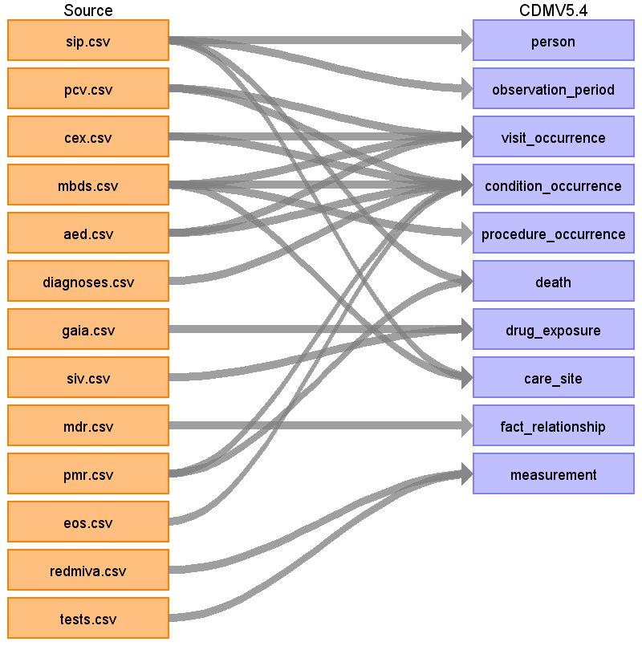

Figure 2: Overview of VID-OMOP CDM v5.4 ETL diagram

### 3.1.1 Target table: person

The target table **person** is populated with the information from the source table **SIP**.

#### 3.1.1.1 From sip to person

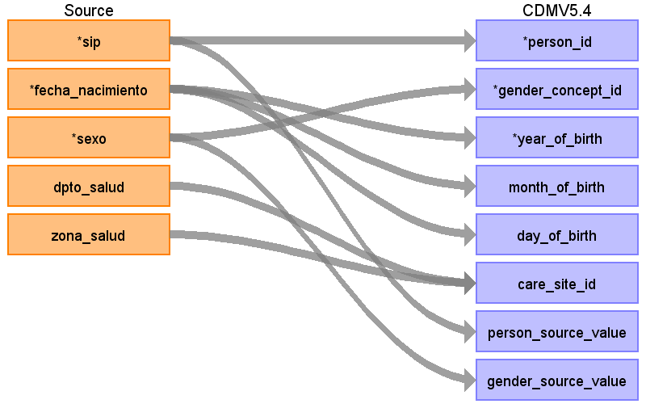

Figure 3: sip to person mapping diagram

Table 3: sip to person mapping description

| Destination Field | Source Field | Logic | Comment |
| --- | --- | --- | --- |
| *person_id* | *sip* | Each different pseudonimyzed ID is converted to an integer starting with 1. | Autogenerate. |
| *gender_concept_id* | *sexo* | case_when( *sexo* == ‘Male’ ~ 8507, *sexo* == ‘Female’ ~ 8532, T ~ NA_integer_) | When *sexo* is ‘Male’, the *gender_concept_id* is ‘8507: Male’. When *sexo* is ‘Female’ the *gender_concept_id* is ‘8532: Female’. Otherwise, drop person: after the mapping of the *gender_concept_id*,… |
| *year_of_birth* | *fecha_nacimiento* | str_sub(*fecha_nacimiento*, 1, 4) \|> as.integer() | *fecha_nacimiento* is a Date format variable (YYYY-mm-dd). |
| *month_of_birth* | *fecha_nacimiento* | str_sub(*fecha_nacimiento*, 6, 7) \|> as.integer() | *fecha_nacimiento* is a Date format variable (YYYY-mm-dd). |
| *day_of_birth* | *fecha_nacimiento* | str_sub(*fecha_nacimiento*, 9, 10) \|> as.integer() | *fecha_nacimiento* is a Date format variable (YYYY-mm-dd). |
| *birth_datetime* | *fecha_nacimiento* | *fecha_nacimiento* | *fecha_nacimiento* in Date format (YYYY-mm-dd). |
| *race_concept_id* |  |  | 0 |
| *ethnicity_concept_id* |  |  | 0 |
| *location_id* |  |  | NA_integer_ |
| *provider_id* |  |  | NA_integer_ |
| *care_site_id* | *dpto_salud*, *zona_salud* | Variables *dpto_salud* and *zona_salud* are converted to a *care_site_id* (see the **care_site** target table). |  |
| *person_source_value* | *sip* |  |  |
| *gender_source_value* | *sexo* |  |  |
| *gender_source_concept_id* |  |  | 0 |
| *race_source_value* |  |  | NA_character_ |
| *race_source_concept_id* |  |  | 0 |
| *ethnicity_source_value* |  |  | NA_character_ |
| *ethnicity_source_concept_id* |  |  | 0 |

### 3.1.2 Target table: observation_period

The target table **observation_period** is populated with the information from the source table **SIP**.

#### 3.1.2.1 From sip to observation_period

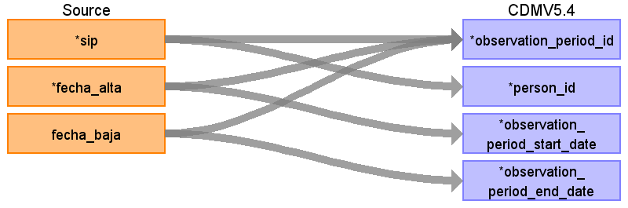

Figure 4: sip to observation_period mapping diagram

Table 4: sip to observation_period mapping description

| Destination Field | Source Field | Logic | Comment |
| --- | --- | --- | --- |
| *observation_period_id* | *sip*, *fecha_alta*, *and fecha_baja* | Autogenerate. Create a new observation period (integer) for each person and different observation periods (*fecha_alta* to *fecha_baja*). |  |
| *person_id* | *sip* |  |  |
| *observation_period_start_date* | *fecha_alta* |  |  |
| *observation_period_end_date* | *fecha_baja* |  |  |
| *period_type_concept_id* |  |  | All observation periods are obtained from the Population Information System (SIP). The records in **SIP** were created when an encounter is produced (without specifying the type). The category that be… |

### 3.1.3 Target table: visit_occurrence

The target table **visit_occurrence** is populated with the information from the source tables **PCV**, **CEX**, **MBDS** and **AED**.

In the mapping process of the visit occurrence, we will create the following intermediate tables with the *visit_occurrence_id* and the *diag_cod* together:

- **from_pcv_to_visit_occurrence**.
- **from_cex_to_visit_occurrence**.
- **from_mbds_to_visit_occurrence**.
- **from_aed_to_visit_occurrence**.

#### 3.1.3.1 From pcv to visit_occurrence

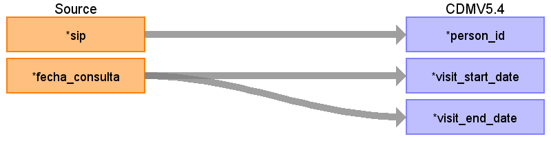

Figure 5: pcv to visit_occurrence mapping diagram

Table 5: pcv to visit_occurrence mapping description

| Destination Field | Source Field | Logic | Comment |
| --- | --- | --- | --- |
| *visit_occurrence_id* |  |  | Autogenerate: from 1 to n_pcv when source table is **PCV**. |
| *person_id* | *sip* |  |  |
| *visit_concept_id* |  |  | In **PCV** there are primary care visits. The Concept ID is ‘9202: Outpatient Visit’. |
| *visit_start_date* | *fecha_consulta* |  |  |
| *visit_start_datetime* | *fecha_consulta* |  |  |
| *visit_end_date* | *fecha_consulta* |  |  |
| *visit_end_datetime* | *fecha_consulta* |  |  |
| *visit_type_concept_id* |  |  | In **PCV** there are primary care visits. The Concept ID is ‘32834: EHR outpatient note’. |
| *provider_id* |  |  | NA_integer_ |
| *care_site_id* |  |  | NA_integer_ |
| *visit_source_value* |  |  | PCV |
| *visit_source_concept_id* |  |  | 0 |
| *admitted_from_concept_id* |  |  | 0 |
| *admitted_from_source_value* |  |  | NA_character_ |
| *discharged_to_concept_id* |  |  | 0 |
| *discharged_to_source_value* |  |  | NA_character_ |
| *preceding_visit_occurrence_id* |  |  | Once all the source tables that contribute to visit_occurence are populated, we will order the *visit_occurrence_id* for each *person_id* and complete this field. |

#### 3.1.3.2 From cex to visit_occurrence

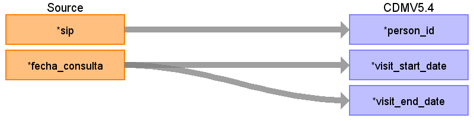

Figure 6: cex to visit_occurrence mapping diagram

Table 6: cex to visit_occurrence mapping description

| Destination Field | Source Field | Logic | Comment |
| --- | --- | --- | --- |
| *visit_occurrence_id* |  |  | Autogenerate: from n_pcv + 1 to n_pcv + n_cex when source table is **CEX**. |
| *person_id* | *sip* |  |  |
| *visit_concept_id* |  |  | In **CEX** there are specialist care visits. The Concept ID is ‘9202: Outpatient Visit’. |
| *visit_start_date* | *fecha_consulta* |  |  |
| *visit_start_datetime* | *fecha_consulta* |  |  |
| *visit_end_date* | *fecha_consulta* |  |  |
| *visit_end_datetime* | *fecha_consulta* |  |  |
| *visit_type_concept_id* |  |  | In **CEX** there are specialist care visits. The Concept ID is ‘32834: EHR outpatient note’. |
| *provider_id* |  |  | NA_integer_ |
| *care_site_id* |  |  | NA_integer_ |
| *visit_source_value* |  |  | CEX |
| *visit_source_concept_id* |  |  | 0 |
| *admitted_from_concept_id* |  |  | 0 |
| *admitted_from_source_value* |  |  | NA_character_ |
| *discharged_to_concept_id* |  |  | 0 |
| *discharged_to_source_value* |  |  | NA_character_ |
| *preceding_visit_occurrence_id* |  |  | Once all the source tables that contribute to visit_occurence are populated, we will order the *visit_occurrence_id* for each *person_id* and complete this field. |

#### 3.1.3.3 From mbds to visit_occurrence

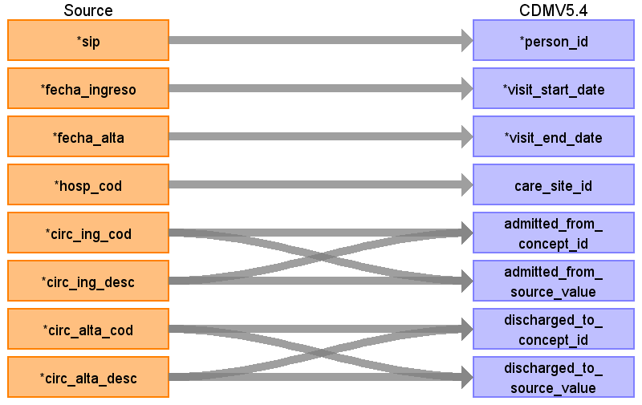

Figure 7: mbds to visit_occurrence mapping diagram

Table 7: mbds to visit_occurrence mapping description

| Destination Field | Source Field | Logic | Comment |
| --- | --- | --- | --- |
| *visit_occurrence_id* |  |  | Autogenerate: from n_pcv + n_cex + 1 to n_pcv + n_cex + n_mbds when source table is **MBDS**. |
| *person_id* | *sip* |  |  |
| *visit_concept_id* |  |  | In **MBDS** there are hospital admissions. The Concept ID is ‘8717: Inpatient Hospital’. |
| *visit_start_date* | *fecha_ingreso* |  |  |
| *visit_start_datetime* | *fecha_ingreso* |  |  |
| *visit_end_date* | *fecha_alta* |  |  |
| *visit_end_datetime* | *fecha_alta* |  |  |
| *visit_type_concept_id* |  |  | In **MBDS** there are hospital discharge summaries. The Concept ID is ‘32824: EHR discharge summary’. |
| *provider_id* |  |  | NA_integer_ |
| *care_site_id* | *hosp_cod* |  |  |
| *visit_source_value* |  |  | MBDS |
| *visit_source_concept_id* |  |  | 0 |
| *admitted_from_concept_id* | *circ_ing_cod*, *circ_ing_desc* |  | Admission Standardized CONCEPT ID. When the *circ_ing_desc* is ‘Programado’ or ‘CMA’ the *admitted_from_concept_id* is ‘0’. When the circ_ing_desc is ‘Urgente’ the *admitted_from_concept_id* is ‘9203:… |
| *admitted_from_source_value* | *circ_ing_cod*, *circ_ing_desc* |  | Source admission code + description. The structure is: {*circ_ing_cod*}: {*circ_ing_desc*}. |
| *discharged_to_concept_id* | *circ_alta_cod*, *circ_alta_desc* |  | Standardized discharge concept ID following the conventions outlined in the *circ_alta* to *discharged_to_concept_id* mapping. |
| *discharged_to_source_value* | *circ_alta_cod*, *circ_alta_desc* |  | Source discharge code + description. The structure is: {*circ_alta_cod*}: {*circ_alta_desc*}. |
| *preceding_visit_occurrence_id* |  |  | Once all the source tables that contribute to visit_occurence are populated, we will order the *visit_occurrence_id* for each *person_id* and complete this field. |

Table 8: circ_alta to discharged_to_concept_id mapping

| circ_alta_cod | circ_alta_desc | discharged_to_concept_id |
| --- | --- | --- |
| -2 | [Sin referencia] | 0 |
| -1 | [Vacio] | 0 |
| 0 | [No aplica] | 0 |
| 1 | Domicilio | 0 |
| 2 | Equipo atención primaria | 0 |
| 3 | Consultas externas | 0 |
| 4 | Hospital de Día | 0 |
| 5 | Unidad de Hospitalización a domicilio | 0 |
| 6 | Alta voluntaria | 0 |
| 7 | Traslado Hospital de agudos | 38004279: General Acute Care Hospital |
| 8 | Traslado Hospital Media larga estancia | 38004277: Long Term Care Hospital |
| 9 | Traslado Residencia o Centro Socio-Sanitario asistido | 8676: Nursing Facility |
| 10 | Éxitus | 0 |
| 11 | Fuga | 0 |
| 13 | Alta disciplinaria | 0 |
| 14 | Unidad de Salud Mental | 38004284: Psychiatric Hospital |
| 15 | Hospitalización | 8717: Inpatient Hospital |
| 16 | Desconocido | 0 |
| 17 | Urgencias | 9203:Emergency Room Visit |
| 26 | COVID-seguimiento | 0 |
| 99 | Otros | 0 |

#### 3.1.3.4 From aed to visit_occurrence

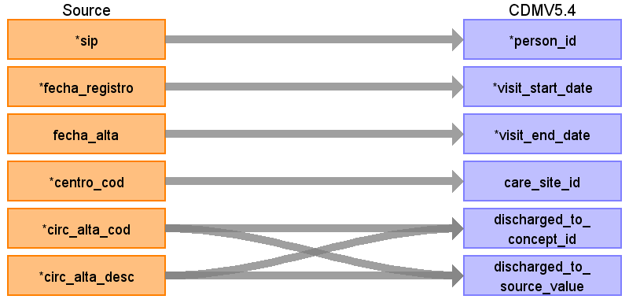

Figure 8: aed to visit_occurrence mapping diagram

Table 9: aed to visit_occurrence mapping description

| Destination Field | Source Field | Logic | Comment |
| --- | --- | --- | --- |
| *visit_occurrence_id* |  |  | Autogenerate: from n_pcv + n_cex + n_mbds + 1 to n_pcv + n_cex + n_mbds + n_aed when source table is **AED**. |
| *person_id* | *sip* |  |  |
| *visit_concept_id* |  |  | In **AED** there are emergency visits. The Concept ID is ‘9203: Emergency Room Visit’. |
| *visit_start_date* | *fecha_registro* |  |  |
| *visit_start_datetime* | *fecha_registro* |  |  |
| *visit_end_date* | *fecha_alta* |  |  |
| *visit_end_datetime* | *fecha_alta* |  |  |
| *visit_type_concept_id* |  |  | In **AED** there are emergency visits. The Concept ID is ‘32826: EHR emergency room note’. |
| *provider_id* |  |  | NA_integer_ |
| *care_site_id* |  |  | NA_integer_ |
| *visit_source_value* |  |  | AED |
| *visit_source_concept_id* |  |  | 0 |
| *admitted_from_concept_id* |  |  | 0 |
| *admitted_from_source_value* |  |  | NA_character_ |
| *discharged_to_concept_id* | *circ_alta_cod*, *circ_alta_desc* |  | Standardized discharge concept ID following the conventions outlined in the *circ_alta* to *discharged_to_concept_id* mapping. |
| *discharged_to_source_value* | *circ_alta_cod*, *circ_alta_desc* |  | Source discharge code + description. The structure is: {*circ_alta_cod*}: {*circ_alta_desc*}. |
| *preceding_visit_occurrence_id* |  |  | Once all the source tables that contribute to visit_occurence are populated, we will order the *visit_occurrence_id* for each *person_id* and complete this field. |

### 3.1.4 Target table: condition_occurrence

The target table **condition_occurrence** is populated with the information from the source tables **PCV**, **CEX**, **MBDS**, **AED**, **DIAGNOSES**, and **EOS**.

#### 3.1.4.1 From pcv to condition_occurrence

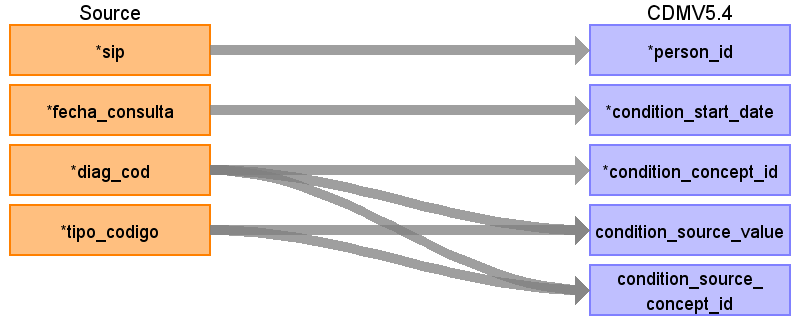

Figure 9: pcv to condition_occurrence mapping diagram

Table 10: pcv to condition_occurrence mapping description

| Destination Field | Source Field | Logic | Comment |
| --- | --- | --- | --- |
| *condition_occurrence_id* |  |  | Autogenerate. When in the same visit there are duplicate conditions, they will be collapsed. |
| *person_id* | *sip* |  |  |
| *condition_concept_id* | *diag_cod* |  | Standardized CONCEPT ID from ICD9CM or ICD10ES codes. |
| *condition_start_date* | *fecha_consulta* |  |  |
| *condition_start_datetime* | *fecha_consulta* |  |  |
| *condition_end_date* |  |  | NA_Date_ |
| *condition_end_datetime* |  |  | NA_Date_ |
| *condition_type_concept_id* |  |  | In **PCV** there are primary care visits. The Concept ID is ‘32834: EHR outpatient note’. |
| *condition_status_concept_id* |  |  | When source table is **PCV**, **CEX**, **AED**, or **DIAGNOSES**, the *condition_status_concept_id* is ‘32893: Confirmed diagnosis’. |
| *stop_reason* |  |  | NA_character_ |
| *provider_id* |  |  | NA_integer_ |
| *visit_occurrence_id* |  |  | Retrieve the *visit_occurrence_id* from the intermediate table **from_pcv_to_visit_occurrence**. |
| *visit_detail_id* |  |  | NA_integer_ |
| *condition_source_value* | *tipo_codigo*, *diag_cod* |  | The ICD9CM or ICD10ES code. *tipo_codigo* flags if the code is ICD9CM or ICD10ES. |
| *condition_source_concept_id* | *tipo_codigo*, *diag_cod* |  | ICD9CM or ICD10ES CONCEPT ID. |
| *condition_status_source_value* |  |  | PCV |

#### 3.1.4.2 From cex to condition_occurrence

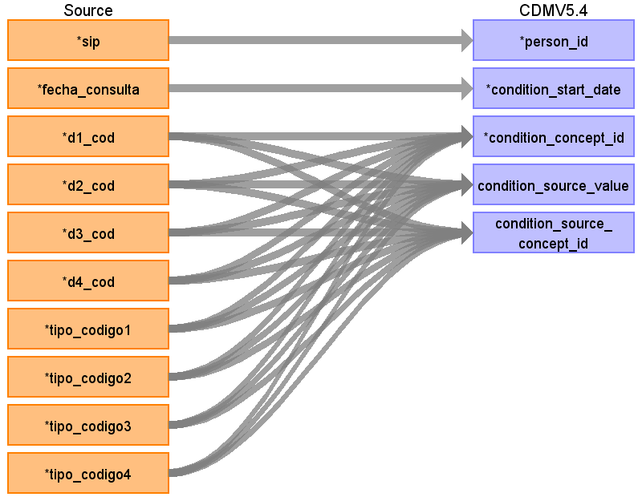

Figure 10: cex to condition_occurrence mapping diagram

Table 11: cex to condition_occurrence mapping description

| Destination Field | Source Field | Logic | Comment |
| --- | --- | --- | --- |
| *condition_occurrence_id* |  |  | Autogenerate. When in the same visit there are duplicate conditions, they will be collapsed. |
| *person_id* | *sip* |  |  |
| *condition_concept_id* | *d1_cod*, *d2_cod*, *d3_cod*, *d4_cod* | In each **CEX** visit there are up to 4 diagnosis codes. Each distinct code is mapped in a different row. | Standardized CONCEPT ID from ICD9CM or ICD10ES codes. |
| *condition_start_date* | *fecha_consulta* |  |  |
| *condition_start_datetime* | *fecha_consulta* |  |  |
| *condition_end_date* |  |  | NA_Date_ |
| *condition_end_datetime* |  |  | NA_Date_ |
| *condition_type_concept_id* |  |  | In **CEX** there are specialist care visits. The Concept ID is ‘32834: EHR outpatient note’. |
| *condition_status_concept_id* |  |  | When source table is **PCV**, **CEX**, **AED**, or **DIAGNOSES**, the *condition_status_concept_id* is ‘32893: Confirmed diagnosis’. |
| *stop_reason* |  |  | NA_character_ |
| *provider_id* |  |  | NA_integer_ |
| *visit_occurrence_id* |  |  | Retrieve the ‘visit_occurrence_id’ from the intermediate table **from_cex_to_visit_occurrence**. |
| *visit_detail_id* |  |  | NA_integer_ |
| *condition_source_value* | *tipo_codigo1*, *tipo_codigo2*, *tipo_codigo3*, *tipo_codigo4*, *d1_cod*, *d2_cod*, *d3_cod*, *d4_cod* |  | The ICD9CM or ICD10ES code. *tipo_codigo* flags if the code is ICD9CM or ICD10ES. |
| *condition_source_concept_id* | *tipo_codigo1*, *tipo_codigo2*, *tipo_codigo3*, *tipo_codigo4*, *d1_cod*, *d2_cod*, *d3_cod*, *d4_cod* |  | ICD9CM or ICD10ES CONCEPT ID. |
| *condition_status_source_value* |  |  | CEX |

#### 3.1.4.3 From mbds to condition_occurrence

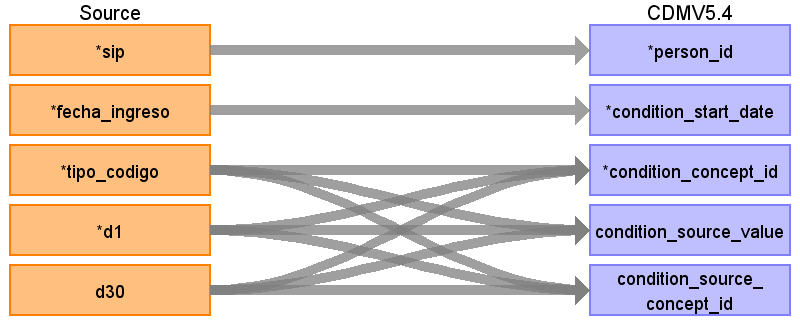

Figure 11: mbds to condition_occurrence mapping diagram

Table 12: mbds to condition_occurrence mapping description

| Destination Field | Source Field | Logic | Comment |
| --- | --- | --- | --- |
| *condition_occurrence_id* |  |  | Autogenerate. When in the same visit there are duplicate conditions, they will be collapsed. |
| *person_id* | *sip* |  |  |
| *condition_concept_id* | from *d1* to *d30* | In each mbds visit there are up to 30 diagnosis codes. Each distinct code is mapped in a different row. | Standardized CONCEPT ID from ICD9CM or ICD10ES codes. There are up to 30 diagnostic codes. However, for the sake of simplicity only *d1* and *d30* are depicted in the diagram. |
| *condition_start_date* | *fecha_ingreso* |  |  |
| *condition_start_datetime* | *fecha_ingreso* |  |  |
| *condition_end_date* |  |  | NA_Date_ |
| *condition_end_datetime* |  |  | NA_Date_ |
| *condition_type_concept_id* |  |  | In **MBDS** there are hospital discharge summaries. The Concept ID is ‘32824: EHR discharge summary’. |
| *condition_status_concept_id* |  |  | When source table is **MBDS**, the condition_status_concept_id is ‘32903: Primary discharge diagnosis’ (when the concept comes from *d1*) and ‘32909: Secondary discharge diagnosis’ when the concept co… |
| *stop_reason* |  |  | NA_character_ |
| *provider_id* |  |  | NA_integer_ |
| *visit_occurrence_id* |  |  | Retrieve the visit_occurrence_id from the intermediate table **from_mbds_to_visit_occurrence**. |
| *visit_detail_id* |  |  | NA_integer_ |
| *condition_source_value* | *tipo_codigo*, *d1*:*d30* |  | The ICD9CM or ICD10ES code. tipo_codigo flags if the code is ICD9CM or ICD10ES. |
| *condition_source_concept_id* | *tipo_codigo*, *d1*:*d30* |  | ICD9CM or ICD10ES CONCEPT ID. |
| *condition_status_source_value* |  |  | MBDS |

#### 3.1.4.4 From aed to condition_occurrence

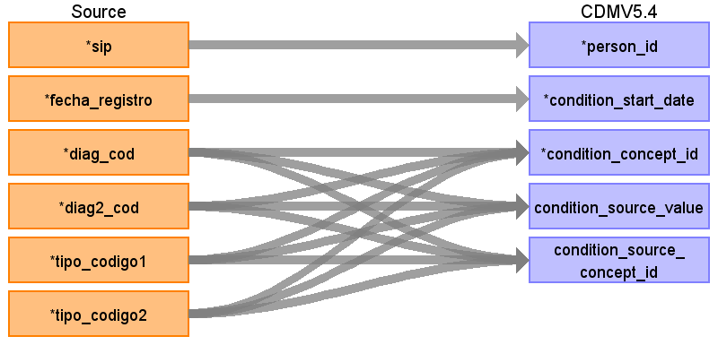

Figure 12: aed to condition_occurrence mapping diagram

Table 13: aed to condition_occurrence mapping description

| Destination Field | Source Field | Logic | Comment |
| --- | --- | --- | --- |
| *condition_occurrence_id* |  |  | Autogenerate. When in the same visit there are duplicate conditions, they will be collapsed. |
| *person_id* | *sip* |  |  |
| *condition_concept_id* | *diag_cod*, *diag2_cod* | In each aed visit there are up to 2 diagnosis codes. Each distinct code is mapped in a different row. | Standardized CONCEPT ID from ICD9CM or ICD10ES codes. |
| *condition_start_date* | *fecha_registro* |  |  |
| *condition_start_datetime* | *fecha_registro* |  |  |
| *condition_end_date* |  |  | NA_Date_ |
| *condition_end_datetime* |  |  | NA_Date_ |
| *condition_type_concept_id* |  |  | **AED** are emergency visits. The Concept ID is ‘32826: EHR emergency room note’. |
| *condition_status_concept_id* |  |  | When source table is **PCV**, **CEX**, **AED**, or **DIAGNOSES**, the *condition_status_concept_id* is ‘32893: Confirmed diagnosis’. |
| *stop_reason* |  |  | NA_character_ |
| *provider_id* |  |  | NA_integer_ |
| *visit_occurrence_id* |  |  | Retrieve the ‘visit_occurrence_id’ from the intermediate table **from_aed_to_visit_occurrence**. |
| *visit_detail_id* |  |  | NA_integer_ |
| *condition_source_value* | *tipo_codigo1*, *tipo_codigo2*, *diag_cod*, *diag2_cod* |  | The ICD9CM or ICD10ES code. *tipo_codigo* flags if the code is ICD9CM or ICD10ES. |
| *condition_source_concept_id* | *tipo_codigo1*, *tipo_codigo2*, *diag_cod*, *diag2_cod* |  | ICD9CM or ICD10ES CONCEPT ID. |
| *condition_status_source_value* |  |  | AED |

#### 3.1.4.5 From diagnoses to condition_occurrence

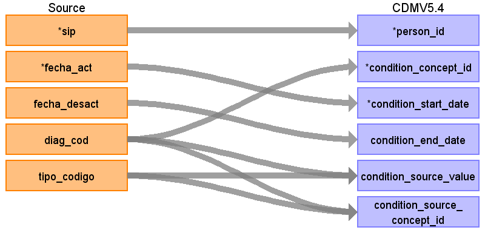

Figure 13: diagnoses to condition_occurrence mapping diagram

Table 14: diagnoses to condition_occurrence mapping description

| Destination Field | Source Field | Logic | Comment |
| --- | --- | --- | --- |
| *condition_occurrence_id* |  |  | Autogenerate. When in the same visit there are duplicate conditions, they will be collapsed. |
| *person_id* | *sip* |  |  |
| *condition_concept_id* | *diag_cod* |  | Standardized CONCEPT ID from ICD9CM or ICD10ES codes. |
| *condition_start_date* | *fecha_act* |  |  |
| *condition_start_datetime* | *fecha_act* |  |  |
| *condition_end_date* | *fecha_desact* |  | *condition_end_date* only is captured when the source table is **DIAGNOSES**. |
| *condition_end_datetime* | *fecha_desact* |  |  |
| *condition_type_concept_id* |  |  | **DIAGNOSES** are confirmed diagnoses. The Concept ID is ‘32817: EHR’. |
| *condition_status_concept_id* |  |  | When source table is **PCV**, **CEX**, **AED**, or **DIAGNOSES**, the *condition_status_concept_id* is ‘32893: Confirmed diagnosis’. |
| *stop_reason* |  |  | NA_character_ |
| *provider_id* |  |  | NA_integer_ |
| *visit_occurrence_id* |  |  | NA_integer_ |
| *visit_detail_id* |  |  | NA_integer_ |
| *condition_source_value* | *tipo_codigo*, *diag_cod* |  | The ICD9CM or ICD10ES code. *tipo_codigo* flags if the code is ICD9CM or ICD10ES. |
| *condition_source_concept_id* | *tipo_codigo*, *diag_cod* |  | ICD9CM or ICD10ES CONCEPT ID. |
| *condition_status_source_value* |  |  | **DIAGNOSES** |

#### 3.1.4.6 From mdr to condition_occurrence

From **MDR** we are creating pregnancy-related condition_occurrences in order to create pregnancy eras.

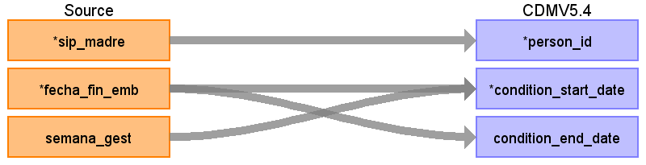

Figure 14: mdr to condition_occurrence mapping diagram

Table 15: mdr to condition_occurrence mapping description

| Destination Field | Source Field | Logic | Comment |
| --- | --- | --- | --- |
| *condition_occurrence_id* |  |  | Autogenerate |
| *person_id* | *sip* |  |  |
| *condition_concept_id* |  |  | ‘4336958: Term pregnancy’. |
| *condition_start_date* | *fecha_fin_emb*, *semana_gest* | *fecha_fin_emb* %m-% weeks(*semana_gest*) |  |
| *condition_start_datetime* | *fecha_fin_emb*, *semana_gest* | *fecha_fin_emb* %m-% weeks(*semana_gest*) |  |
| *condition_end_date* | *fecha_fin_emb* |  |  |
| *condition_end_datetime* | *fecha_fin_emb* |  |  |
| *condition_type_concept_id* |  |  | ‘32879: Registry’. |
| *condition_status_concept_id* |  |  | ‘32906: Resolved condition’. |
| *stop_reason* |  |  | livebirth |
| *provider_id* |  |  | NA_integer_ |
| *visit_occurrence_id* |  |  | NA_integer_ |
| *visit_detail_id* |  |  | NA_integer_ |
| *condition_source_value* |  |  | NA_character_ |
| *condition_source_concept_id* |  |  | NA_integer_ |
| *condition_status_source_value* |  |  | MDR |

#### 3.1.4.7 From eos to condition_occurrence

From **EOS** we are creating pregnancy-related condition_occurrences in order to create pregnancy eras.

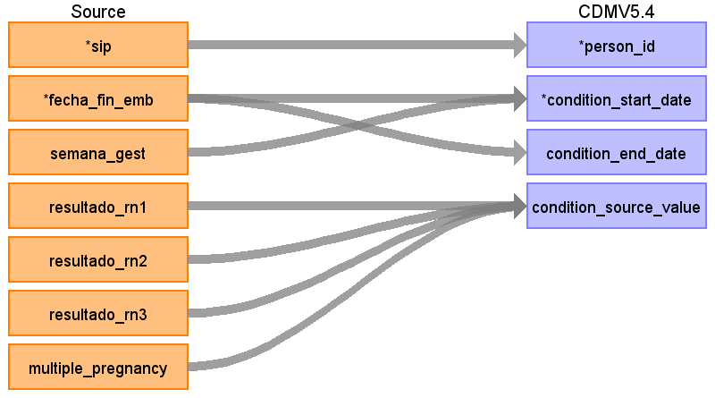

Figure 15: eos to condition_occurrence mapping diagram

Table 16: eos to condition_occurrence mapping description

| Destination Field | Source Field | Logic | Comment |
| --- | --- | --- | --- |
| *condition_occurrence_id* |  |  | Autogenerate. When in the same visit there are duplicate conditions, they will be collapsed. |
| *person_id* | *sip* |  |  |
| *condition_concept_id* |  |  | ‘4142469: Pregnancy time period’. |
| *condition_start_date* | *fecha_fin_emb*, *semana_gest* | *fecha_fin_emb* %m-% weeks(*semana_gest*) |  |
| *condition_start_datetime* | *fecha_fin_emb*, *semana_gest* | *fecha_fin_emb* %m-% weeks(*semana_gest*) |  |
| *condition_end_date* | *fecha_fin_emb* |  |  |
| *condition_end_datetime* | *fecha_fin_emb* |  |  |
| *condition_type_concept_id* |  |  | In the **EOS** there are information obtained through EHR. The Concept ID is ‘32817: EHR’. |
| *condition_status_concept_id* |  |  | ‘32906: Resolved condition’. |
| *stop_reason* |  |  | End of pregnancy |
| *provider_id* |  |  | NA_integer_ |
| *visit_occurrence_id* |  |  | NA_integer_ |
| *visit_detail_id* |  |  | NA_integer_ |
| *condition_source_value* | *multiple_pregnancy*, *resultado_rn1*, *resultado_rn2*, *resultado_rn3* |  | Result of pregnancy. The structure is: {*multiple_pregnancy*}: {*resultado_rn1*}/{*resultado_rn2*}/{*resultado_rn3*} |
| *condition_source_concept_id* |  |  | NA_integer |
| *condition_status_source_value* |  |  | EOS |

### 3.1.5 Target table: procedure_occurrence

The target table **procedure_occurrence** is populated with the information from the source table **MBDS**.

#### 3.1.5.1 From mbds to procedure_occurrence

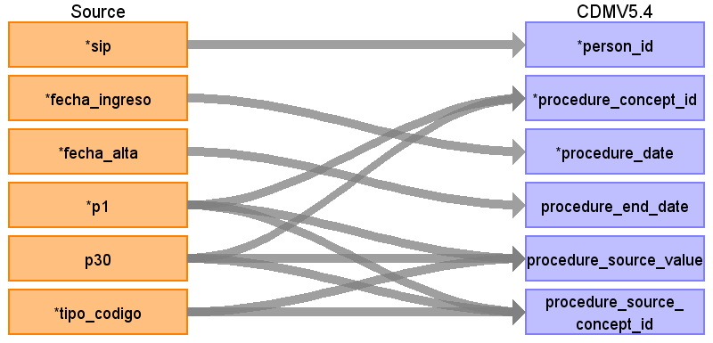

Figure 16: mbds to procedure_occurrence mapping diagram

Table 17: mbds to procedure_occurrence mapping description

| Destination Field | Source Field | Logic | Comment |
| --- | --- | --- | --- |
| *procedure_occurrence_id* |  |  |  |
| *person_id* | *sip* |  |  |
| *procedure_concept_id* | from *p1* to *p30* |  | Standardized Concept ID from ICD9CM or ICD10ES procedure code. There are up to 30 procedure codes. However, for the sake of simplicity only *p1* and *p30* are depicted in the diagram. |
| *procedure_date* | *fecha_ingreso* |  | Procedures, usually take place in the same day. The accurate procedure_date is some date between *fecha_ingreso* and *fecha_alta*. |
| *procedure_datetime* | *fecha_ingreso* |  |  |
| *procedure_end_date* | *fecha_alta* |  | Procedures, usually take place in the same day. The accurate procedure_date is some date between *fecha_ingreso* and *fecha_alta*. |
| *procedure_end_datetime* | *fecha_alta* |  |  |
| *procedure_type_concept_id* |  |  | ‘32824: EHR discharge summary’. |
| *modifier_concept_id* |  |  | NA_integer_ |
| *quantity* |  |  | NA_integer_ |
| *provider_id* |  |  | NA_integer_ |
| *visit_occurrence_id* |  |  | Use the intermediate table **from_mbds_to_visit_occurrence**. |
| *visit_detail_id* |  |  | NA_integer_ |
| *procedure_source_value* | *tipo_codigo*, *p1*:*p30* |  | The ICD9CM or ICD10ES code. *tipo_codigo* flags if the code is ICD9CM or ICD10ES |
| *procedure_source_concept_id* | *tipo_codigo*, *p1*:*p30* |  | The CONCEPT ID from the ICD9CM or ICD10ES code |
| *modifier_source_value* |  |  | MBDS |

### 3.1.6 Target table: death

The target table **death** is populated with the information from the source tables **SIP**, and **PMR**.

#### 3.1.6.1 From sip to death

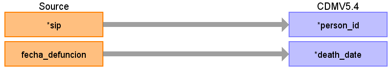

Figure 17: sip to death mapping diagram

Table 18: sip to death mapping description

| Destination Field | Source Field | Logic | Comment |
| --- | --- | --- | --- |
| *person_id* | *sip* |  |  |
| *death_date* | *fecha_defuncion* |  |  |
| *death_datetime* | *fecha_defuncion* |  |  |
| *death_type_concept_id* |  |  | ‘32848: Government report’. |
| *cause_concept_id* |  |  | NA_integer_ |
| *cause_source_value* |  |  | NA_character_ |
| *cause_source_concept_id* |  |  | NA_integer_ |

#### 3.1.6.2 From pmr to death

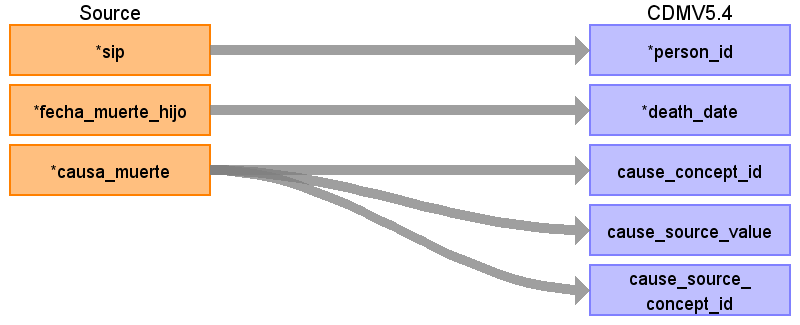

Figure 18: pmr to death mapping diagram

Table 19: pmr to death mapping description

| Destination Field | Source Field | Logic | Comment |
| --- | --- | --- | --- |
| *person_id* | *sip* |  |  |
| *death_date* | *fecha_muerte_hijo* |  |  |
| *death_datetime* | *fecha_muerte_hijo* |  |  |
| *death_type_concept_id* |  | ‘32879: Registry’. |  |
| *cause_concept_id* | *causa_muerte* |  | the cause of death is an standardized code (SNOMED) from *causa_muerte*. |
| *cause_source_value* | *causa_muerte* |  | The *cause_source_value* is *causa_muerte*, which is an ICD9CM or ICD10ES code. |
| *cause_source_concept_id* | *causa_muerte* |  | The *cause_source_concept_id* is the corresponding *concept_id* from the ICD9CM or ICD10ES code. Otherwise NA_integer_. |

**Important**

For now, it is not possible to perform the ETL process for the ‘**From pmr to death**’ information. The sex of the newborn is currently unavailable, and in accordance with the OMOP conventions, these newborn records cannot be stored in the **person** table.

### 3.1.7 Target table: drug_exposure

The target table **drug_exposure** is populated with the information from the source tables **GAIA**, and **SIV**.

#### 3.1.7.1 From gaia to drug_exposure

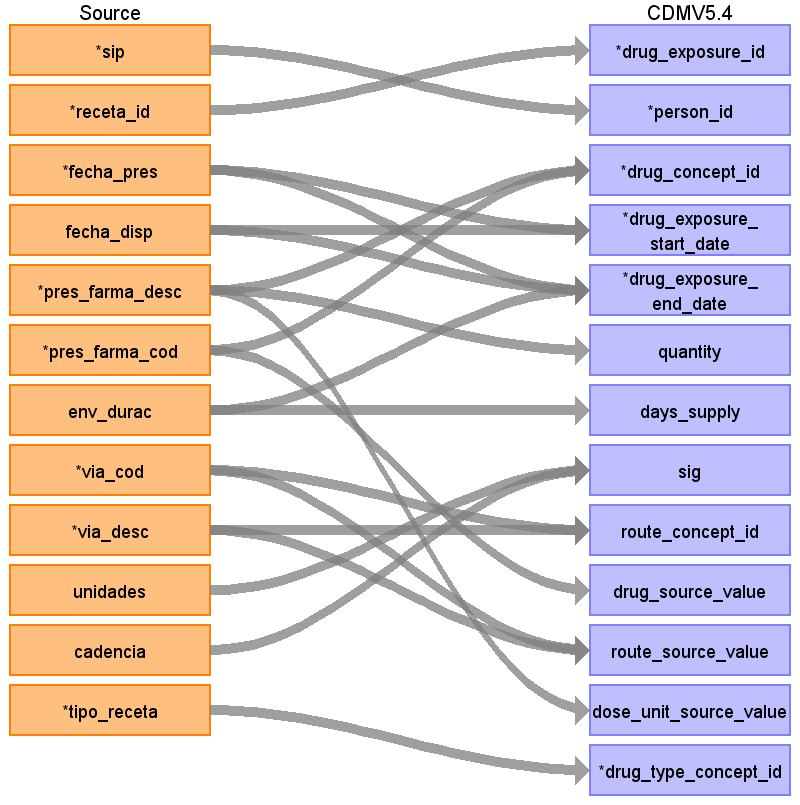

Figure 19: gaia to drug_exposure mapping diagram

Table 20: gaia to drug_exposure mapping description

| Destination Field | Source Field | Logic | Comment |
| --- | --- | --- | --- |
| *drug_exposure_id* | *receta_id* |  | Autogenerate an integer for each unique *receta_id*. |
| *person_id* | *sip* |  |  |
| *drug_concept_id* | *pres_farma_cod*, *pres_farma_desc* |  | Obtain Standard CONCEPT ID using *pres_farma_desc* and *pres_farma_cod* with the help of the USAGI tool. |
| *drug_exposure_start_date* | *fecha_disp*, *fecha_pres* |  | When !is.na(*fecha_disp*), the *drug_exposure_start_date* is *fecha_disp*. When is.na(*fecha_disp*), the *drug_exposure_start_date* is *fecha_pres* (although this is not an actual exposure, as the pat… |
| *drug_exposure_start_datetime* | *fecha_disp*, *fecha_pres* |  |  |
| *drug_exposure_end_date* |  |  | *drug_exposure_end_date* is calculated as *drug_exposure_start_date* %m+% days(*env_durac*). |
| *drug_exposure_end_datetime* |  |  |  |
| *verbatim_end_date* |  |  | NA_Date_ |
| *drug_type_concept_id* |  |  | When !is.na(*fecha_disp*), the CONCEPT ID is 32825: EHR dispensing record. When is.na(*fecha_disp*), the CONCEPT ID is 32838: EHR prescription. |
| *stop_reason* |  |  | NA_character_ |
| *refills* |  |  | NA_integer_ |
| *quantity* | *pres_farma_desc* |  | Extracted from *pres_farma_desc*. |
| *days_supply* | *env_durac* |  |  |
| *sig* | *unidades*, *cadencia* |  | Dosage using *unidades* and *cadencia* variables. The structure is: ‘{*unidades*} form(s) each {*cadencia*} hours’. |
| *route_concept_id* | *via_cod* |  | Standardized CONCEPT ID route code. |
| *lot_number* |  |  | 0 |
| *provider_id* |  |  | NA_integer_ |
| *visit_occurrence_id* |  |  |  |
| *visit_detail_id* |  |  | NA_integer_ |
| *drug_source_value* | *pres_farma_cod* |  |  |
| *drug_source_concept_id* |  |  | NA_integer_ |
| *route_source_value* | *via_desc* |  |  |
| *dose_unit_source_value* |  | extract dose unit from *pres_farma_desc*. |  |

#### 3.1.7.2 From siv to drug_exposure

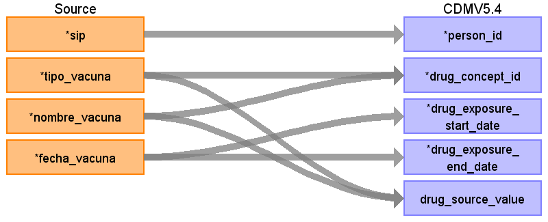

Figure 20: siv to drug_exposure mapping diagram

Table 21: siv to drug_exposure mapping description

| Destination Field | Source Field | Logic | Comment |
| --- | --- | --- | --- |
| *drug_exposure_id* |  |  |  |
| *person_id* | *sip* |  |  |
| *drug_concept_id* |  |  | ingredient, or drug comp, or branded drug Standard CONCEPT ID |
| *drug_exposure_start_date* | *fecha_vacuna* |  |  |
| *drug_exposure_start_datetime* | *fecha_vacuna* |  |  |
| *drug_exposure_end_date* | *fecha_vacuna* |  |  |
| *drug_exposure_end_datetime* | *fecha_vacuna* |  |  |
| *verbatim_end_date* |  |  | NA_Date_ |
| *drug_type_concept_id* | *tipo_vacuna*, *nombre_vacuna* |  | the CONCEPT ID is ‘32818: EHR administration record’. |
| *stop_reason* |  |  | NA_character_ |
| *refills* |  |  | 0 |
| *quantity* |  |  | 1 |
| *days_supply* |  |  | 0 |
| *sig* |  |  | NA_character_ |
| *route_concept_id* |  |  | The *route_concept_id* is ‘4302612: Intramuscular’ (we will check if some vaccine has another administration route different to intramuscular). |
| *lot_number* |  |  | 0 |
| *provider_id* |  |  | NA_integer_ |
| *visit_occurrence_id* |  |  | NA_integer_ |
| *visit_detail_id* |  |  | NA_integer_ |
| *drug_source_value* | *tipo_vacuna*, *nombre_vacuna* |  | ingredient, or drug comp, or branded |
| *drug_source_concept_id* | *tipo_vacuna*, *nombre_vacuna* |  | ingredient, or drug comp, or branded CONCEPT ID |
| *route_source_value* |  |  | Intramuscular |
| *dose_unit_source_value* |  |  | NA_character_ |

### 3.1.8 Target table: care_site

In the Valencia region, the public health care is divided into 24 health departments. The departments, by their part, contain one or more hospitals and are divided into health basic areas.

The target table **care_site** is populated with the information from the source tables **SIP** and **MBDS**.

#### 3.1.8.1 From sip to care_site

In the **SIP** table, we populate the departments and the health basic areas.

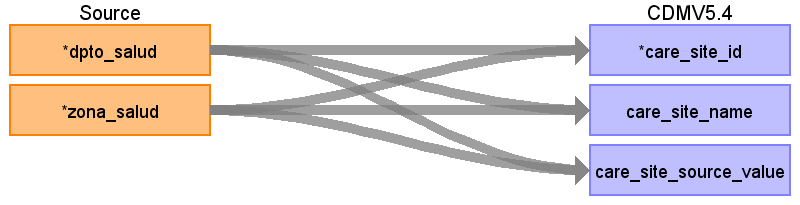

Figure 21: sip to care_site mapping diagram

Table 22: sip to care_site mapping description

| Destination Field | Source Field | Logic | Comment |
| --- | --- | --- | --- |
| *care_site_id* | *dpto_salud*, *zona_salud* |  | Autogenerate |
| *care_site_name* | *dpto_salud*, *zona_salud* | Paste the *dpto_salud* (department) and the *zona_salud* (basic health area) names. | In this field it is indicated the ‘name’ of the department and the basic health area (separated with a semicolon symbol ‘;’) assigned to each individual. |
| *place_of_service_concept_id* |  |  | The CONCEPT ID is ‘38004226: Ambulatory Health Service Clinic / Center’. |
| *location_id* |  |  | NA_integer_ |
| *care_site_source_value* | *dpto_salud*, *zona_salud* | Paste the *dpto_salud* (department) and the *zona_salud* (basic health area) codes. | In this field it is indicated the original ‘codes’ and ‘names’ of the department and the basic health area assigned to each individual. The structure is: {*dpto_salud_cod*}: {*dpto_salud_name*}; {*zon… |
| *place_of_service_source_value* |  |  | Zona básica de salud. |

#### 3.1.8.2 From mbds to care_site

In the **MBDS** table, we have the hospital information. There is a master table with the corresponding names and codes of all the hospitals within VID. This master table is independent of the study/project extraction. Therefore, it will be used in order to map the care_site information related to hospitals.

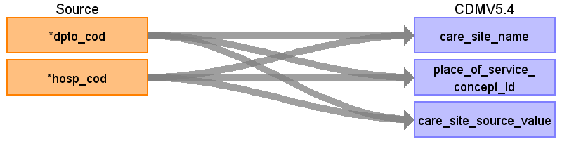

mbds to care_site mapping diagram

Table 23: mbds to care_site mapping description

| Destination Field | Source Field | Logic | Comment |
| --- | --- | --- | --- |
| *care_site_id* | *dpto_cod*, *hosp_cod* |  | Autogenerate |
| *care_site_name* | *dpto_cod*, *hosp_cod* |  | In this field it is indicated the ‘name’ of the hospital. |
| *place_of_service_concept_id* |  |  | The CONCEPT ID is ‘38004515: Hospital’. |
| *location_id* |  |  | NA_integer_ |
| *care_site_source_value* | *hosp_cod* |  | In this field it is indicated the ‘code’ of the hospital. |
| *place_of_service_source_value* |  |  | Hospital |

### 3.1.9 Target table: fact_relationship

The target table **fact_relationship** is populated with the information from the source table **MDR**.

#### 3.1.9.1 From mdr to fact_relationship

This table cannot be populated because we don’t have information about the sex of the children, and we cannot create a person entry for them. We have included this section in anticipation of the possibility of obtaining the sex of the newborns in the future.

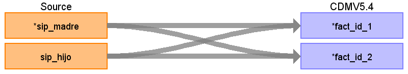

Figure 22: mdr to fact_relationship mapping diagram

Use the standard concepts in order to obtain the bidirectional association: Person, 1, Person, 2, mother of. Person, 2, Person, 1, child of.

Table 24: mdr to fact relationship mapping description

[output not shown]

### 3.1.10 Target table: measurement

The target table **measurement** is populated with the information from the source tables **TESTS** and **REDMIVA**.

#### 3.1.10.1 From tests to measurement

The **TESTS** table contains information on diastolic blood pressure (mmHg), systolic blood pressure (mmHg), height (cm), weight (kg) and BMI ($kg/m^2$).

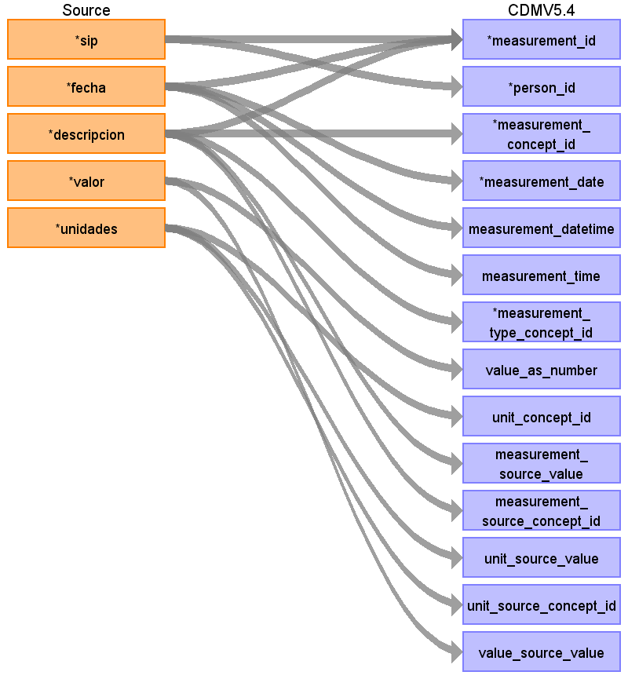

tests to measurement mapping diagram

Table 25: tests to measurement mapping description

Destination Field

Source Field

Logic

Comment

*measurement_id*

*sip*, *fecha*, *descripcion*

Autogenerate

*person_id*

*sip*

*measurement_concept_id*

*descripcion*

Depending on the *descripcion* variable in the source table as follows:

```
- Tensión arterial diastólica: 3012888 (Diastolic blood pressure).

- Tensión Arterial Sistólica: 3004249 (Systolic blood pressure).

- Talla: 3015514 (Body height --standing).

- Peso/Peso Medio: 3025315 (Body weight).

- Índice de Masa Corporal: 3038553 (Body mass index (BMI) [Ratio]).
```

*measurement_date*

*fecha*

*measurement_datetime*

*fecha*

*measurement_time*

*fecha*

*measurement_type_concept_id*

*descripcion*

For all records, ‘32836: EHR physical examination’, except for BMI which is ‘32880: Standard algorithm’.

*operator_concept_id*

0

*value_as_number*

*valor*

0

*value_as_concept_id*

NA_integer_

*unit_concept_id*

*unidades*

Depending on the *unidades* variable in the source table as follows:

```
- cm: 8582 (centimeter).

- kg: 9529 (kilogram).

- kg/m2: 9531 (kilogram per square meter).

- mmHg: 8876 (millimeter mercury column).
```

*range_low*

0

*range_high*

0

*provider_id*

NA_integer_

*visit_occurrence_id*

NA_integer_

*visit_detail_id*

NA_integer_

*measurement_source_value*

*descripcion*

*measurement_source_concept_id*

*descripcion*

*unit_source_value*

*unidades*

*unit_source_concept_id*

*unidades*

*value_source_value*

*valor*

*measurement_event_id*

NA_integer_

*meas_event_field_concept_id*

0

#### 3.1.10.2 From redmiva to measurement

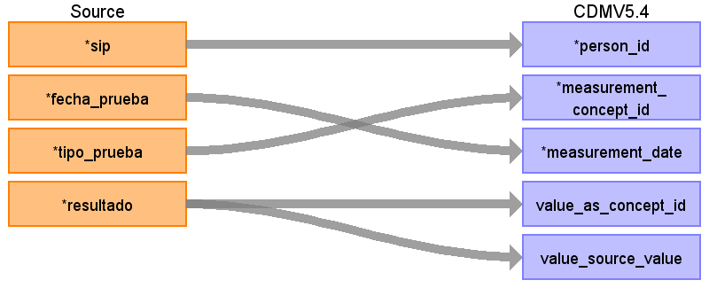

redmiva to measurement mapping diagram

Table 26: redmiva to measurement mapping description

| Destination Field | Source Field | Logic | Comment |
| --- | --- | --- | --- |
| *measurement_id* |  |  | Autogenerate |
| *person_id* | *sip* |  |  |
| *measurement_concept_id* | *tipo_prueba* |  | When *tipo_prueba* is (PCR) in the source table, the concept id is ‘586310: Measurement of Severe acute respiratory syndrome coronavirus 2 (SARS-CoV-2) Genetic material using Molecular method), while … |
| *measurement_date* | *fecha_prueba* |  |  |
| *measurement_datetime* | *fecha_prueba* |  |  |
| *measurement_time* | *fecha_prueba* |  |  |
| *measurement_type_concept_id* |  |  | ‘32856: Lab’. |
| *operator_concept_id* |  |  | 0 |
| *value_as_number* |  |  | 0 |
| *value_as_concept_id* | *resultado* |  | ‘Positive: 45884084’. |
| *unit_concept_id* |  |  | 0 |
| *range_low* |  |  | 0 |
| *range_high* |  |  | 0 |
| *provider_id* |  |  | NA_integer_ |
| *visit_occurrence_id* |  |  | NA_integer_ |
| *visit_detail_id* |  |  | NA_integer_ |
| *measurement_source_value* |  |  | 0 |
| *measurement_source_concept_id* |  |  | 0 |
| *unit_source_value* |  |  | 0 |
| *unit_source_concept_id* |  |  | 0 |
| *value_source_value* | *resultado* |  | Positivo |
| *measurement_event_id* |  |  | NA_integer_ |
| *meas_event_field_concept_id* |  |  | 0 |

### 3.1.11 Instance table: cdm_source

The CDM_SOURCE table contains detail about the source database and the process used to transform the data into the OMOP Common Data Model.

Table 27: cdm_source table description

| Destination Field | Logic | Value in the last instance |
| --- | --- | --- |
| cdm_source_name | The name of the CDM instance. | Valencia Health System Integrated Database (VID) - CONSIGN project |
| cdm_source_abbreviation | The abbreviation of the CDM instance. | vid_consign |
| cdm_holder | The holder of the CDM instance. | FISABIO-HSRP |
| source_description | The description of the CDM instance. | Instance of the CONSIGN project utilizing the VID data |
| source_documentation_reference | The reference to the source documentation. | https://github.com/frasansa/VID2OMOP/tree/main/doc |
| cdm_etl_reference | Version of the ETL script used. e.g. link to the Git release. | https://github.com/frasansa/VID2OMOP |
| source_release_date | The date the data was extracted from the source system. | 2022-01-01 |
| cdm_release_date | The date the ETL script was completed. Typically this is after the source_release_date. | 2024-06-14 |
| cdm_version | Version of the OMOP CDM used as string. e.g. v5.4 | 5.4 |
| cdm_version_concept_id | The Concept Id representing the version of the CDM. | 798878 |
| vocabulary_version | Version of the OMOP standardised vocabularies loaded | v5.0 31-AUG-23 |

## 3.2 Part II Overview

In the Part II of the ETL we perform the following steps:

1. The content of the **condition_occurrence**, **procedure_occurrence**, and **drug_exposure** tables, whose standardized concepts domain was different from their respective table, has been relocated. To achieve this, the target tables **device_exposure** and **observation** have been created.
2. The *sig* and *drug_exposure_end_date* of the **drug_exposure** table are revised for some drugs of interest.
3. The target table **source_to_concept_map** has been created to store the source-to-concept mapping.

### 3.2.1 Target table: device_exposure

The target table **device_exposure** has been created to include rows from **drug_exposure** and **procedure_occurrence** where the standardized domain is ‘Device’.

#### 3.2.1.1 From drug_exposure to device_exposure

The rows in the **device_exposure** table that originate from the **drug_exposure** table are populated using the following code snippet:

```r
# from_drug_exposure_vid_0_to_device_exposure---------------------------------
from_drug_exposure_vid_0_to_device_exposure <- drug_exposure_vid_0 |>
  filter(drug_concept_id %in% device_drug_exposure_concept_ids) |>
  arrange(drug_exposure_id) |>
  transmute(
    device_exposure_id = 1:n(),
    person_id = person_id,
    device_concept_id = drug_concept_id,
    device_exposure_start_date = drug_exposure_start_date,
    device_exposure_start_datetime = drug_exposure_start_datetime,
    device_exposure_end_date = drug_exposure_end_date,
    device_exposure_end_datetime = drug_exposure_end_datetime,
    device_type_concept_id = drug_type_concept_id,
    unique_device_id = NA_integer_,
    production_id = NA_integer_,
    quantity = 1,
    provider_id = NA_integer_,
    visit_occurrence_id = NA_integer_,
    visit_detail_id = NA_integer_,
    device_source_value = drug_source_value,
    device_source_concept_id = drug_source_concept_id,
    unit_concept_id = 0,
    unit_source_value = 0,
    unit_source_concept_id = 0
  )
```

#### 3.2.1.2 From procedure_occurrence to device_exposure

The rows in the **device_exposure** table that originate from the **procedure_occurrence** table are populated using the following code snippet:

```r
# from_procedure_occurrence_vid_0_to_device_exposure--------------------------
from_procedure_occurrence_vid_0_to_device_exposure <- procedure_occurrence_vid_0 |>
  filter(procedure_concept_id %in% device_procedure_occurrence_concept_ids) |>
  arrange(procedure_occurrence_id) |>
  transmute(
    device_exposure_id = 1:n() + last_drug_exposure_vid_0_device_id,
    person_id = person_id,
    device_concept_id = procedure_concept_id,
    device_exposure_start_date = procedure_date,
    device_exposure_start_datetime = procedure_datetime,
    device_exposure_end_date = procedure_end_date,
    device_exposure_end_datetime = procedure_end_datetime,
    device_type_concept_id = procedure_type_concept_id,
    unique_device_id = NA_integer_,
    production_id = NA_integer_,
    quantity = 1,
    provider_id = NA_integer_,
    visit_occurrence_id = NA_integer_,
    visit_detail_id = NA_integer_,
    device_source_value = procedure_source_value,
    device_source_concept_id = procedure_source_concept_id,
    unit_concept_id = 0,
    unit_source_value = 0,
    unit_source_concept_id = 0
  )
```

### 3.2.2 Target table: observation

The target table **observation** has been created to include rows from **condition_occurrence** and **drug_exposure** where the standardized domain is ‘Observation’.

#### 3.2.2.1 From condition_occurrence to observation

The rows in the **observation** table that originate from the **condition_occurrence** table are populated using the following code snippet:

```r
# from_condition_occurrence_vid_0_to_observation----------------------------
from_condition_occurrence_vid_0_to_observation <- condition_occurrence_vid_0_observation |>
  transmute(
    observation_id = 1:n(),
    person_id = person_id,
    observation_concept_id = condition_concept_id,
    observation_date = condition_start_date,
    observation_datetime = condition_start_datetime,
    observation_type_concept_id = condition_type_concept_id,
    value_as_number = 0,
    value_as_string = NA_character_,
    value_as_concept_id = value_as_concept_id,
    qualifier_concept_id = 0,
    unit_concept_id = 0,
    provider_id = NA_integer_,
    visit_occurrence_id = visit_occurrence_id,
    visit_detail_id = NA_integer_,
    observation_source_value = condition_source_value,
    observation_source_concept_id = condition_source_concept_id,
    unit_source_value = NA_character_,
    qualifier_source_value = NA_character_,
    value_source_value = NA_character_,
    observation_event_id = NA_integer_,
    obs_event_field_concept_id = 0
  )
```

#### 3.2.2.2 From drug_exposure to observation

The rows in the **observation** table that originate from the **drug_exposure** table are populated using the following code snippet:

```r
# from_drug_exposure_vid_0 to observation-----------------------------------
from_drug_exposure_vid_0_to_observation <- drug_exposure_vid_0 |>
  filter(drug_concept_id %in% observation_drug_concept_ids) |>
  transmute(
    observation_id = 1:n() + last_condition_occurrence_vid_0_observation_id,
    person_id = person_id,
    observation_concept_id = drug_concept_id,
    observation_date = drug_exposure_start_date,
    observation_datetime = drug_exposure_start_datetime,
    observation_type_concept_id = drug_type_concept_id,
    value_as_number = 0,
    value_as_string = NA_character_,
    value_as_concept_id = 0,
    qualifier_concept_id = 0,
    unit_concept_id = 0,
    provider_id = NA_integer_,
    visit_occurrence_id = visit_occurrence_id,
    visit_detail_id = NA_integer_,
    observation_source_value = drug_source_value,
    observation_source_concept_id = drug_source_concept_id,
    unit_source_value = NA_character_,
    qualifier_source_value = NA_character_,
    value_source_value = NA_character_,
    observation_event_id = NA_integer_,
    obs_event_field_concept_id = 0
  )
```

### 3.2.3 Target table: source_to_concept_map

The source to concept map table is recommended for use in ETL processes to maintain local source codes which are not available as Concepts in the Standardized Vocabularies, and to establish mappings for each source code into a Standard Concept as target_concept_ids that can be used to populate the Common Data Model tables. The SOURCE_TO_CONCEPT_MAP table is no longer populated with content within the Standardized Vocabularies published to the OMOP community.

## 3.3 Part III Overview

In this part, the derived tables **condition_era** and **drug_era** are created.

### 3.3.1 Derived table: condition_era

A Condition Era is defined as a span of time when the Person is assumed to have a given condition. Similar to Drug Eras, Condition Eras are chronological periods of Condition Occurrence. Combining individual Condition Occurrences into a single Condition Era serves two purposes:

It allows aggregation of chronic conditions that require frequent ongoing care, instead of treating each Condition Occurrence as an independent event.

It allows aggregation of multiple, closely timed doctor visits for the same Condition to avoid double-counting the Condition Occurrences. For example, consider a Person who visits her Primary Care Physician (PCP) and who is referred to a specialist. At a later time, the Person visits the specialist, who confirms the PCP’s original diagnosis and provides the appropriate treatment to resolve the condition. These two independent doctor visits should be aggregated into one Condition Era.

### 3.3.2 Derived table: drug_era

A Drug Era is defined as a span of time when the Person is assumed to be exposed to a particular active ingredient. A Drug Era is not the same as a Drug Exposure: Exposures are individual records corresponding to the source when Drug was delivered to the Person, while successive periods of Drug Exposures are combined under certain rules to produce continuous Drug Eras.

# 4 VOCABULARY MAPPING

Some vocabularies available in ATHENA and some not available in ATHENA have been used for mapping.

## 4.1 Vocabularies available in ATHENA

This section provides an overview of the vocabulary mapping step. The Table 28 shows the source code vocabularies available in the database, included in ATHENA and downloaded in csv tables.

Table 28: Source vocabularies

| Vocabulary | Reference Link | Description | Data Domains |
| --- | --- | --- | --- |
| ICD9CM | [ICD9CM](https://eciemaps.mscbs.gob.es/ecieMaps/browser/index_9_mc.html) | International Classification of Diseases, 9th revision, Clinical Modification. | *condition_occurrence* |
| ICD10ES | [ICD10ES](https://eciemaps.mscbs.gob.es/ecieMaps/browser/index_10_mc.html) | International Classification of Diseases, 10th revision, Clinical Modification, Spanish Edition. | *condition_occurrence* |

## 4.2 Vocabularies not available in ATHENA

In addition to the ATHENA vocabularies, the vocabularies *VID Drugs*, *VID Routes* and *VID Vaccines* have been used. Their implementation can be found in the script 2_02_ETL_Implementation_part_2_CONSIGN.qmd.

# APPENDIX 1. SOURCE DATA MODEL

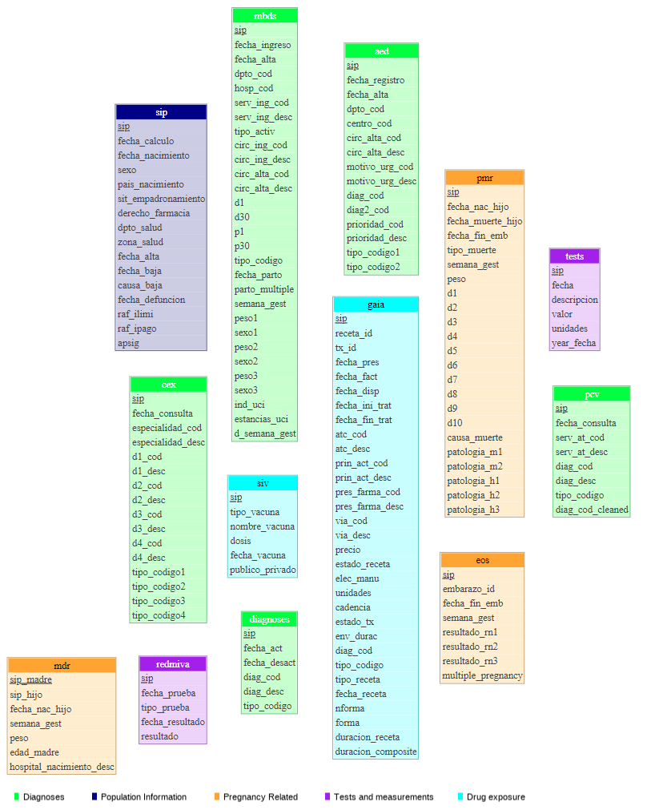

Figure 23: VID data model diagram

# APPENDIX 2. DATA DICTIONARY

## 4.3 Tables

Table 29: Source tables description

| Source Table | English Name | Description |
| --- | --- | --- |
| SIP | Population Information System | Population and social information of the VID population (such as sex, birth date, income, etc.). A record is created when anyone, resident or foreigner (e.g. tourists), contacts the system. Everyone i… |
| PCV | Primary Care Visit | Information of the primary care visits (general practice) |
| CEX | Speciality Visit | Information of the specialist care visits |
| MBDS | Minimum Basic Data Set | Hospital admission minimum basic data set. Records are triggered by hospital admissions and capture the information about anyone who has an admission, regardless of their residency status. |
| AED | Accident and Emergency Department | Information of the hospital Accident and Emergency Department visits. The **AED** visits that led to hospitalization can be linked with the **MBDS**. |
| DIAGNOSES | Diagnoses | Information about the active (and non-active) diagnoses of the population. |
| GAIA | Pharmaceutical Information | **GAIA** contains the information about Pharmaceutical information. It is the result of the combination about 3 tables (prescription, dispensing and treatment episodes). Each prescription has an indiv… |
| SIV | Vaccines Information System | **SIV** contains the information about the vaccines. Records of the administration of any type of vaccine are found (those of the usual calendar, those specific of pregnancy, flu campaign, vaccines ag… |
| MDR | Metabolic Disease Register | Metabolic disease register records. As the register contains the information of all livebirths it can be considered as a birth register. It allows to link the mother person id with the newborn person … |
| PMR | Perinatal Mortality Register | Perinatal mortality register records. It contains the information about fetal deaths occurred from 21 gestational weeks and newborn deaths produced to 28 days after birth. |
| EOS | Electronic Obstetric Sheet | Electronic obstetric sheet. It contains the information about the pregnancy follow-up. It is used in order to detect spontaneous abortions (and to confirm births and stillbirths). |
| TESTS | Tests | Tests results and measurements, such as blood pressure, height, weight and body mass index (bmi). |
| CONG | Congenital anomalies | In this base are collected the information about congenital anomalies (This table is not mapped into the OMOP CDM yet). |
| REDMIVA | Microbiological Surveillance Network | It contains the information about COVID-19 test results. |

## 4.4 Fields

Table 30: Source fields description

[output not shown]

[output cut: 329 more lines]